# Assignment 2 : Grandparents on duty - Report

Cristina Davila Gonzalez

9/15/2020

# Grandparents on duty: datasets and variables

*On this year’s Back to School season, most of public schools worldwide have decided to go remote. Coming from a current context of diaspora and mass migration of young/adult professionals, where sometimes elders are left in charge of their grandchildren, I decided to take a look at similar family scenarios in the U.S. where grandparents are a key factor in making remote-learning feasible for their underage relatives.*

For this exercise I used person-level variables from the **American Community Survey 2018** (ACS 1-year data) to eventually generate supporting information on the research question, specifically in the state of **Illinois**. As I developed my analysis on the selected variables, I decided to generate two datasets; one with **underage enrolled students** and another one considering **grandparents of 50 years old and up** in charge of their grandchildren.

Regarding the age interval selected for the grandparents dataset, I initially wanted to set the age in 65 and up, however, during the previous assignment I realized I could consider more individuals than the 813 resulted from this first analysis of variables. This led to the consideration of a lower number, and after investigating more on senior communities in the U.S., I decided to set 50 years as my base age, as according to the **American Association of Retired Persons 2018 Survey**, it is also the average age at first-grandchild in the country.

```r
u18people_data <-read_csv("u18people.csv")
o50people_data <-read_csv("O50people.csv")
```

## List of Variables

1. **Age** (AGEP) (continuous) 1.1 Age of population under 18 within tract 1.2 Age of population over 50 within tract
2. **School Enrollment** (SCH) (categorical)
3. **Grade Level Attending** (SCHG) (categorical)
4. **Self-care difficulty** (FDDRSP) (categorical) 4.1 Self-care difficulty on population under 18 within tract 4.2 Self-care difficulty on population over 50 within tract
5. **Grandparents responsible for grandchildren** (GCR) (categorical)
6. **Total person’s income** (PINCP) (continuous)

# Distribution of Continuous Variables

## Descriptive statistics

Calculation of variables summaries

```r
ageu18_summary <-summary(u18people_data$AGEP)
ageu18_conf_int <- t.test(u18people_data$AGEP)
ageu18_sd <-sd(u18people_data$AGEP)
ageo50_summary <-summary(o50people_data$AGEP)
ageo50_conf_int <- t.test(o50people_data$AGEP)
ageo50_sd <-sd(o50people_data$AGEP)
income_summary <-summary(o50people_data$PINCP)
income_conf_int <-t.test(o50people_data$PINCP)
income_sd <-sd(o50people_data$PINCP)
```

Display of variables summaries

```r
summary_table <- tibble(
  Statistic = c("Sample mean",
                "Median",
                "Standard deviation",
                "Interquartile range",
                "Population mean (95% confidence)"),
  `Median age: Underage Students (< 18 years)` = c(prettyNum(ageu18_summary["Mean"], digits=3),
                           ageu18_summary["Median"],
                           prettyNum(ageu18_sd, digits = 3),
                           paste(ageu18_summary["1st Qu."],"to",
                                 ageu18_summary["3rd Qu."]),
                           paste(prettyNum(ageu18_conf_int$conf.int[1],
                                           digits=3), "to",
                                 prettyNum(ageu18_conf_int$conf.int[2],
                                               digits=3))),
 `Median age: Potential Grandparents (>50)` = c(prettyNum(ageo50_summary["Mean"], digits=3),
                           ageo50_summary["Median"],
                           prettyNum(ageo50_sd, digits = 3),
                           paste(ageo50_summary["1st Qu."],"to",
                                 ageo50_summary["3rd Qu."]),
                           paste(prettyNum(ageo50_conf_int$conf.int[1],
                                           digits=3), "to",
                                 prettyNum(ageo50_conf_int$conf.int[2],
                                               digits=3))),
 `Total Grandparent's income (>50)` = c(prettyNum(income_summary["Mean"], digits=3),
                           income_summary["Median"],
                           prettyNum(income_sd, digits = 3),
                           paste(income_summary["1st Qu."],"to",
                                 income_summary["3rd Qu."]),
                           paste(prettyNum(income_conf_int$conf.int[1],
                                           digits=3), "to",
                                 prettyNum(income_conf_int$conf.int[2],
                                               digits=3))))

knitr::kable(summary_table, caption = "Characteristics of census tracts in Illinois")
```

Characteristics of census tracts in Illinois

| Statistic | Median age: Underage Students (< 18 years) | Median age: Potential Grandparents (>50) | Total Grandparent’s income (>50) |
| --- | --- | --- | --- |
| Sample mean | 8.9 | 63.6 | 33240 |
| Median | 9 | 62 | 21100 |
| Standard deviation | 5.19 | 8.71 | 45688 |
| Interquartile range | 4 to 13 | 57 to 69 | 8800 to 45000 |
| Population mean (95% confidence) | 8.84 to 8.97 | 63.3 to 64 | 31237 to 35243 |

## Histograms

### Median Age: Underage Students

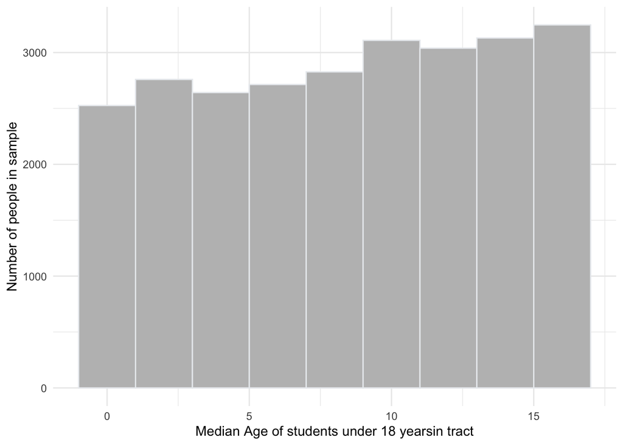

```r
ggplot(u18people_data, aes(x = AGEP)) +
  geom_histogram(fill= "gray", color="#e9ecef", binwidth = 2) +
  theme_minimal() +
  scale_x_continuous(name = "Median Age of students under 18 yearsin tract") +
  scale_y_continuous(name = "Number of people in sample")
```

### Median Age: Potential Grandparents

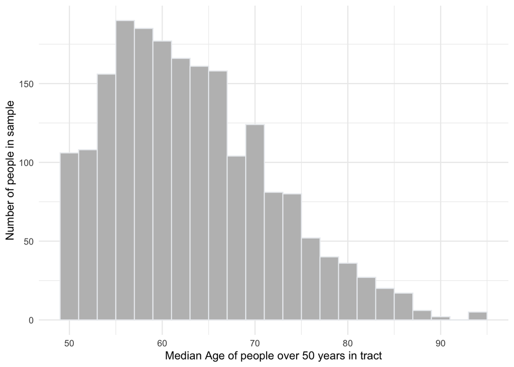

```r
ggplot(o50people_data, aes(x = AGEP)) +
  geom_histogram(fill= "gray", color="#e9ecef", binwidth = 2) +
  theme_minimal() +
  scale_x_continuous(name = "Median Age of people over 50 years in tract") +
  scale_y_continuous(name = "Number of people in sample")
```

### Total Potential Grandparent’s Income

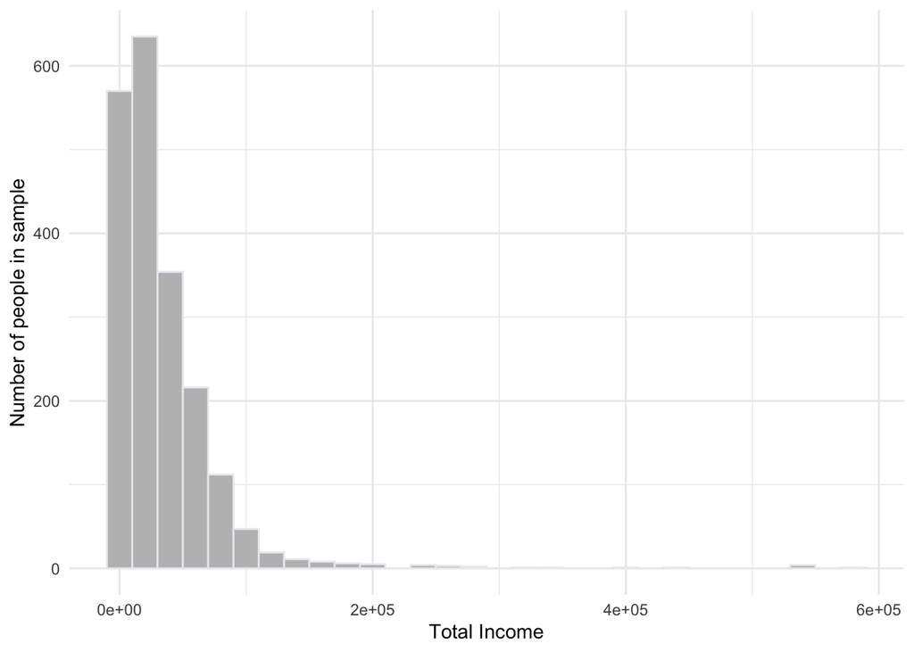

```r
ggplot(o50people_data, aes(x = PINCP)) +
  geom_histogram(fill= "gray", color="#e9ecef", bins = 30) +
  theme_minimal() +
  scale_x_continuous(name = "Total Income") +
  scale_y_continuous(name = "Number of people in sample")
```

# Distribution of Categorical Variables

## School Enrollment

T-test for each individual category

```r
na_less3 <- t.test(u18people_data$SCH_label == "N/A (less than 3 years old)")
no_attend <- t.test(u18people_data$SCH_label == "No, has not attended in the last 3 months)")
yes_private <- t.test(u18people_data$SCH_label == "Yes, private school or college or home school")
yes_public <- t.test(u18people_data$SCH_label == "Yes, public school or public college")
```

Table of proportions and confidence intervals

```r
enroll_shares <- tibble(`School Enrollment` = c("N/A (less than 3 years old)",
                                  "No, has not attended in the last 3 months)",
                                  "Yes, private school or college or home school",
                                  "Yes, public school or public college"),
                 `Sample proportion` = c(paste(prettyNum(na_less3$estimate*100,
                                                         digits = 3), "%"),
                                         paste(prettyNum(no_attend$estimate*100,
                                                         digits = 3), "%"),
                                         paste(prettyNum(yes_private$estimate*100,
                                                         digits = 3), "%"),
                                         paste(prettyNum(yes_public$estimate*100,
                                                         digits = 3), "%")),
                 `95-percent confidence interval` = c(
                   paste(prettyNum(na_less3$conf.int[1]*100, digits=3),
                         "% to ",
                         prettyNum(na_less3$conf.int[2]*100, digits=3),
                         "%", sep=""),
                   paste(prettyNum(no_attend$conf.int[1]*100, digits=3),
                         "% to ",
                         prettyNum(no_attend$conf.int[2]*100, digits=3),
                         "%", sep=""),
                   paste(prettyNum(yes_private$conf.int[1]*100, digits=3),
                         "% to ",
                         prettyNum(yes_private$conf.int[2]*100, digits=3),
                         "%", sep=""),
                   paste(prettyNum(yes_public$conf.int[1]*100, digits=3),
                         "% to ",
                         prettyNum(yes_public$conf.int[2]*100, digits=3),
                         "%", sep="")))


knitr::kable(enroll_shares, caption = "Census tracts in Illinois")
```

[output not shown]

## Grade Level Attending

T-test for each individual category

```r
na_noattend <- t.test(u18people_data$SCHG_label == "N/A (not attending school)")
nursery_pre <- t.test(u18people_data$SCHG_label == "Nursery school/preschool")
k_garten <- t.test(u18people_data$SCHG_label == "Kindergarten")
grade_1 <- t.test(u18people_data$SCHG_label == "Grade 1")
grade_2 <- t.test(u18people_data$SCHG_label == "Grade 2")
grade_3 <- t.test(u18people_data$SCHG_label == "Grade 3")
grade_4 <- t.test(u18people_data$SCHG_label == "Grade 4")
grade_5 <- t.test(u18people_data$SCHG_label == "Grade 5")
grade_6 <- t.test(u18people_data$SCHG_label == "Grade 6")
grade_7 <- t.test(u18people_data$SCHG_label == "Grade 7")
grade_8 <- t.test(u18people_data$SCHG_label == "Grade 8")
grade_9 <- t.test(u18people_data$SCHG_label == "Grade 9")
grade_10 <- t.test(u18people_data$SCHG_label == "Grade 10")
grade_11 <- t.test(u18people_data$SCHG_label == "Grade 11")
grade_12 <- t.test(u18people_data$SCHG_label == "Grade 12")
under_grad <- t.test(u18people_data$SCHG_label == "College undergraduate years (freshman to senior)")
```

Table of proportions and confidence intervals

```r
grade_shares <- tibble(`Grade Level Attending` = c("N/A (not attending school)",
                                  "Nursery school/preschool",
                                  "Kindergarten",
                                  "Grade 1",
                                  "Grade 2",
                                  "Grade 3",
                                  "Grade 4",
                                  "Grade 5",
                                  "Grade 6",
                                  "Grade 7",
                                  "Grade 8",
                                  "Grade 9",
                                  "Grade 10",
                                  "Grade 11",
                                  "Grade 12",
                                  "College undergraduate years"),
                 `Sample proportion` = c(paste(prettyNum(na_noattend$estimate*100,
                                                         digits = 3), "%"),
                                         paste(prettyNum(nursery_pre$estimate*100,
                                                         digits = 3), "%"),
                                          paste(prettyNum(k_garten$estimate*100,
                                                         digits = 3), "%"),
                                         paste(prettyNum(grade_1$estimate*100,
                                                         digits = 3), "%"),
                                         paste(prettyNum(grade_2$estimate*100,
                                                         digits = 3), "%"),
                                          paste(prettyNum(grade_3$estimate*100,
                                                         digits = 3), "%"),
                                         paste(prettyNum(grade_4$estimate*100,
                                                         digits = 3), "%"),
                                         paste(prettyNum(grade_5$estimate*100,
                                                         digits = 3), "%"),
                                         paste(prettyNum(grade_6$estimate*100,
                                                         digits = 3), "%"),
                                         paste(prettyNum(grade_7$estimate*100,
                                                         digits = 3), "%"),
                                         paste(prettyNum(grade_8$estimate*100,
                                                         digits = 3), "%"),
                                         paste(prettyNum(grade_9$estimate*100,
                                                         digits = 3), "%"),
                                         paste(prettyNum(grade_10$estimate*100,
                                                         digits = 3), "%"),
                                         paste(prettyNum(grade_11$estimate*100,
                                                         digits = 3), "%"),
                                         paste(prettyNum(grade_12$estimate*100,
                                                         digits = 3), "%"),
                                         paste(prettyNum(under_grad$estimate*100,
                                                         digits = 3), "%")),
                 `95-percent confidence interval` = c(
                   paste(prettyNum(na_noattend$conf.int[1]*100, digits=3),
                         "% to ",
                         prettyNum(na_noattend$conf.int[2]*100, digits=3),
                         "%", sep=""),
                   paste(prettyNum(nursery_pre$conf.int[1]*100, digits=3),
                         "% to ",
                         prettyNum(nursery_pre$conf.int[2]*100, digits=3),
                         "%", sep=""),
                   paste(prettyNum(k_garten$conf.int[1]*100, digits=3),
                         "% to ",
                         prettyNum(k_garten$conf.int[2]*100, digits=3),
                         "%", sep=""),
                   paste(prettyNum(grade_1$conf.int[1]*100, digits=3),
                         "% to ",
                         prettyNum(grade_1$conf.int[2]*100, digits=3),
                         "%", sep=""),
                   paste(prettyNum(grade_2$conf.int[1]*100, digits=3),
                         "% to ",
                         prettyNum(grade_2$conf.int[2]*100, digits=3),
                         "%", sep=""),
                   paste(prettyNum(grade_3$conf.int[1]*100, digits=3),
                         "% to ",
                         prettyNum(grade_3$conf.int[2]*100, digits=3),
                         "%", sep=""),
                   paste(prettyNum(grade_4$conf.int[1]*100, digits=3),
                         "% to ",
                         prettyNum(grade_4$conf.int[2]*100, digits=3),
                         "%", sep=""),
                   paste(prettyNum(grade_5$conf.int[1]*100, digits=3),
                         "% to ",
                         prettyNum(grade_5$conf.int[2]*100, digits=3),
                         "%", sep=""),
                   paste(prettyNum(grade_6$conf.int[1]*100, digits=3),
                         "% to ",
                         prettyNum(grade_6$conf.int[2]*100, digits=3),
                         "%", sep=""),
                   paste(prettyNum(grade_7$conf.int[1]*100, digits=3),
                         "% to ",
                         prettyNum(grade_7$conf.int[2]*100, digits=3),
                         "%", sep=""),
                   paste(prettyNum(grade_8$conf.int[1]*100, digits=3),
                         "% to ",
                         prettyNum(grade_8$conf.int[2]*100, digits=3),
                         "%", sep=""),
                   paste(prettyNum(grade_9$conf.int[1]*100, digits=3),
                         "% to ",
                         prettyNum(grade_9$conf.int[2]*100, digits=3),
                         "%", sep=""),
                   paste(prettyNum(grade_10$conf.int[1]*100, digits=3),
                         "% to ",
                         prettyNum(grade_10$conf.int[2]*100, digits=3),
                         "%", sep=""),
                   paste(prettyNum(grade_11$conf.int[1]*100, digits=3),
                         "% to ",
                         prettyNum(grade_11$conf.int[2]*100, digits=3),
                         "%", sep=""),
                   paste(prettyNum(grade_12$conf.int[1]*100, digits=3),
                         "% to ",
                         prettyNum(grade_12$conf.int[2]*100, digits=3),
                         "%", sep=""),
                   paste(prettyNum(under_grad$conf.int[1]*100, digits=3),
                         "% to ",
                         prettyNum(under_grad$conf.int[2]*100, digits=3),
                         "%", sep="")))


knitr::kable(grade_shares, caption = "Census tracts in Illinois")
```

Census tracts in Illinois

| Grade Level Attending | Sample proportion | 95-percent confidence interval |
| --- | --- | --- |
| N/A (not attending school) | 21.5 % | 21% to 22% |
| Nursery school/preschool | 7.78 % | 7.45% to 8.1% |
| Kindergarten | 5.13 % | 4.86% to 5.4% |
| Grade 1 | 4.94 % | 4.67% to 5.2% |
| Grade 2 | 5.14 % | 4.87% to 5.41% |
| Grade 3 | 5.5 % | 5.22% to 5.77% |
| Grade 4 | 5.55 % | 5.27% to 5.83% |
| Grade 5 | 5.93 % | 5.65% to 6.22% |
| Grade 6 | 5.89 % | 5.61% to 6.18% |
| Grade 7 | 5.84 % | 5.56% to 6.13% |
| Grade 8 | 5.79 % | 5.51% to 6.08% |
| Grade 9 | 5.89 % | 5.61% to 6.18% |
| Grade 10 | 6.1 % | 5.81% to 6.39% |
| Grade 11 | 5.81 % | 5.52% to 6.09% |
| Grade 12 | 3.04 % | 2.83% to 3.25% |
| College undergraduate years | 0.15 % | 0.103% to 0.197% |

## Self care difficulty

### Self-care difficulty in population under 18 within tract:

T-test for each individual category

```r
yes_diff18 <- t.test(u18people_data$FDDRSP_label == "Yes")
no_diff18 <- t.test(u18people_data$FDDRSP_label == "No")
```

Table of proportions and confidence intervals

```r
scd18_shares <- tibble(`Self care difficulty (underage)` = c("Yes", "No"),
                 `Sample proportion` = c(paste(prettyNum(yes_diff18$estimate*100,
                                                         digits = 3), "%"),
                                         paste(prettyNum(no_diff18$estimate*100,
                                                         digits = 3), "%")),
                 `95-percent confidence interval` = c(
                   paste(prettyNum(yes_diff18$conf.int[1]*100, digits=3),
                         "% to ",
                         prettyNum(yes_diff18$conf.int[2]*100, digits=3),
                         "%", sep=""),
                   paste(prettyNum(no_diff18$conf.int[1]*100, digits=3),
                         "% to ",
                         prettyNum(no_diff18$conf.int[2]*100, digits=3),
                         "%", sep="")))


knitr::kable(scd18_shares, caption = "Census tracts in Illinois")
```

Census tracts in Illinois

| Self care difficulty (underage) | Sample proportion | 95-percent confidence interval |
| --- | --- | --- |
| Yes | 9.13 % | 8.78% to 9.48% |
| No | 90.9 % | 90.5% to 91.2% |

### Self-care difficulty in population over 50 within tract:

T-test for each individual category

```r
yes_diff50 <- t.test(o50people_data$FDDRSP_label == "Yes")
no_diff50 <- t.test(o50people_data$FDDRSP_label == "No")
```

Table of proportions and confidence intervals

```r
scd50_shares <- tibble(`Self care difficulty (over 50)` = c("Yes", "No"),
                 `Sample proportion` = c(paste(prettyNum(yes_diff50$estimate*100,
                                                         digits = 3), "%"),
                                         paste(prettyNum(no_diff50$estimate*100,
                                                         digits = 3), "%")),
                 `95-percent confidence interval` = c(
                   paste(prettyNum(yes_diff50$conf.int[1]*100, digits=3),
                         "% to ",
                         prettyNum(yes_diff50$conf.int[2]*100, digits=3),
                         "%", sep=""),
                   paste(prettyNum(no_diff50$conf.int[1]*100, digits=3),
                         "% to ",
                         prettyNum(no_diff50$conf.int[2]*100, digits=3),
                         "%", sep="")))


knitr::kable(scd50_shares, caption = "Census tracts in Illinois")
```

Census tracts in Illinois

| Self care difficulty (over 50) | Sample proportion | 95-percent confidence interval |
| --- | --- | --- |
| Yes | 9.15 % | 7.88% to 10.4% |
| No | 90.9 % | 89.6% to 92.1% |

## Grandparents responsible for grandchildren: GCR_label

T-test for each individual category

```r
yes_gcr <- t.test(o50people_data$GCR_label == "Yes")
no_gcr <- t.test(o50people_data$GCR_label == "No")
```

Table of proportions and confidence intervals

```r
gcr_shares <- tibble(`Grandparents responsible for grandchildren` = c("Yes", "No"),
                 `Sample proportion` = c(paste(prettyNum(yes_gcr$estimate*100,
                                                         digits = 3), "%"),
                                         paste(prettyNum(no_gcr$estimate*100,
                                                         digits = 3), "%")),
                 `95-percent confidence interval` = c(
                   paste(prettyNum(yes_gcr$conf.int[1]*100, digits=3),
                         "% to ",
                         prettyNum(yes_gcr$conf.int[2]*100, digits=3),
                         "%", sep=""),
                   paste(prettyNum(no_gcr$conf.int[1]*100, digits=3),
                         "% to ",
                         prettyNum(no_gcr$conf.int[2]*100, digits=3),
                         "%", sep="")))


knitr::kable(gcr_shares, caption = "Census tracts in Illinois")
```

Census tracts in Illinois

| Grandparents responsible for grandchildren | Sample proportion | 95-percent confidence interval |
| --- | --- | --- |
| Yes | 30.8 % | 28.8% to 32.8% |
| No | 69.2 % | 67.2% to 71.2% |